# **Bitcoin Forecasting using ARIMA Model**

# ARIMA Combined model

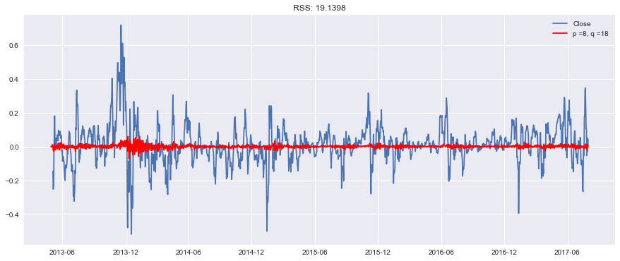

```python
model = ARIMA(ts_logtransformed, order=(8, 1, 18))
results_ARIMA = model.fit(trend= 'nc', disp=-1)
plt.plot(ts_diff_logtrans)
plt.plot(results_ARIMA.fittedvalues, color='red', label = 'p =8, q =18')
RSS =results_ARIMA.fittedvalues-ts_diff_logtrans
RSS.dropna(inplace=True)
plt.title('RSS: %.4f'% sum(RSS**2))
plt.legend(loc='best')
```

### Searching ARIMA parameters.

The following markdown is a python code that helps to evaluate different model performances to evaluate best ARIMA hyperparameters

We can derive the Summary of the ARIMA model as follows explaining the results

```python
#model summary
print(results_ARIMA.summary())
```

```
                             ARIMA Model Results
==============================================================================
Dep. Variable:                D.Close   No. Observations:                 1555
Model:                ARIMA(8, 1, 18)   Log Likelihood                2740.086
Method:                       css-mle   S.D. of innovations              0.042
Date:                Wed, 07 Feb 2018   AIC                          -5426.172
Time:                        07:51:35   BIC                          -5281.743
Sample:                    04-29-2013   HQIC                         -5372.464
                         - 07-31-2017
==================================================================================
                     coef    std err          z      P>|z|      [0.025      0.975]
----------------------------------------------------------------------------------
ar.L1.D.Close     -0.7123        nan        nan        nan         nan         nan
ar.L2.D.Close     -0.7205        nan        nan        nan         nan         nan
ar.L3.D.Close     -1.3382      0.130    -10.305      0.000      -1.593      -1.084
ar.L4.D.Close     -0.3520        nan        nan        nan         nan         nan
ar.L5.D.Close     -0.0952      0.334     -0.285      0.776      -0.750       0.560
ar.L6.D.Close     -0.2128      0.223     -0.955      0.340      -0.650       0.224
ar.L7.D.Close      0.3625      0.100      3.639      0.000       0.167       0.558
ar.L8.D.Close      0.0694        nan        nan        nan         nan         nan
ma.L1.D.Close      0.7088        nan        nan        nan         nan         nan
ma.L2.D.Close      0.6782        nan        nan        nan         nan         nan
ma.L3.D.Close      1.3134      0.146      9.014      0.000       1.028       1.599
ma.L4.D.Close      0.3814        nan        nan        nan         nan         nan
ma.L5.D.Close      0.1067      0.319      0.334      0.738      -0.519       0.732
ma.L6.D.Close      0.3328      0.223      1.494      0.135      -0.104       0.769
ma.L7.D.Close     -0.2380        nan        nan        nan         nan         nan
ma.L8.D.Close      0.0121      0.060      0.204      0.839      -0.105       0.129
ma.L9.D.Close      0.1043      0.052      1.987      0.047       0.001       0.207
ma.L10.D.Close     0.0566      0.042      1.348      0.178      -0.026       0.139
ma.L11.D.Close     0.0677      0.061      1.106      0.269      -0.052       0.188
ma.L12.D.Close     0.0720      0.054      1.331      0.183      -0.034       0.178
ma.L13.D.Close     0.1192      0.055      2.159      0.031       0.011       0.227
ma.L14.D.Close     0.1541      0.043      3.574      0.000       0.070       0.239
ma.L15.D.Close     0.1045        nan        nan        nan         nan         nan
ma.L16.D.Close     0.1386      0.037      3.721      0.000       0.066       0.212
ma.L17.D.Close     0.0940        nan        nan        nan         nan         nan
ma.L18.D.Close     0.0618        nan        nan        nan         nan         nan
                                    Roots
==============================================================================
```

[output cut: 14 more lines]

```
MA.5             0.3652           -1.0033j            1.0677           -0.1944
MA.6             0.3652           +1.0033j            1.0677            0.1944
MA.7             0.4221           -1.0375j            1.1201           -0.1885
MA.8             0.4221           +1.0375j            1.1201            0.1885
MA.9            -0.0137           -1.0800j            1.0801           -0.2520
MA.10           -0.0137           +1.0800j            1.0801            0.2520
MA.11           -1.0188           -0.2429j            1.0473           -0.4627
MA.12           -1.0188           +0.2429j            1.0473            0.4627
MA.13           -1.0705           -0.4347j            1.1554           -0.4386
MA.14           -1.0705           +0.4347j            1.1554            0.4386
MA.15           -0.4901           -1.2321j            1.3261           -0.3103
MA.16           -0.4901           +1.2321j            1.3261            0.3103
MA.17           -0.9658           -1.0497j            1.4264           -0.3684
MA.18           -0.9658           +1.0497j            1.4264            0.3684
------------------------------------------------------------------------------
```

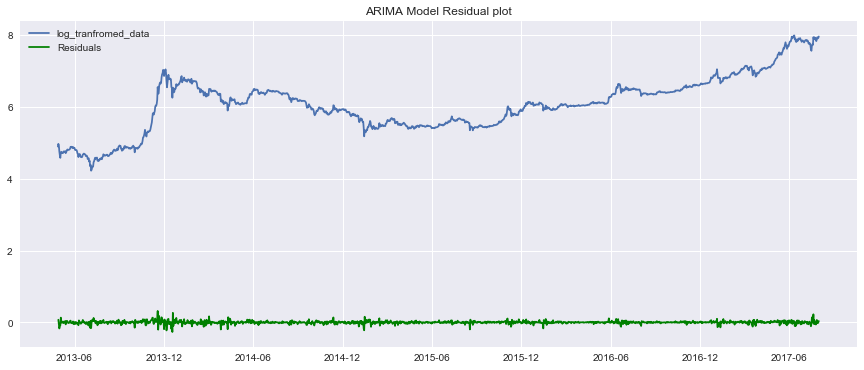

```python
plt.plot(ts_logtransformed, label = 'log_tranfromed_data')
plt.plot(results_ARIMA.resid, color ='green',label= 'Residuals')
plt.title('ARIMA Model Residual plot')
plt.legend(loc = 'best')
```

```
count    1555.000000
mean        0.001525
std         0.041546
min        -0.266607
25%        -0.012462
50%         0.001757
75%         0.017993
max         0.318746
dtype: float64
```

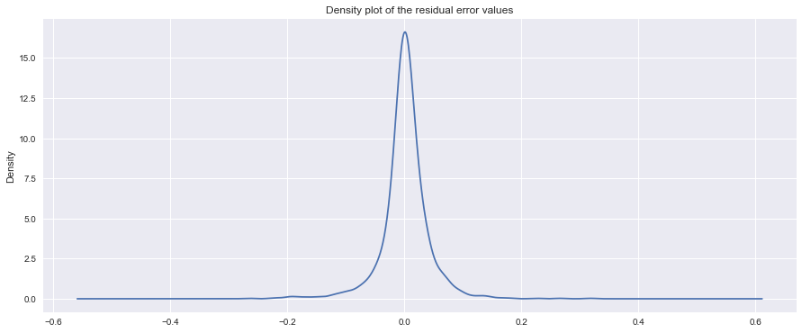

```python
results_ARIMA.resid.plot(kind='kde')
plt.title('Density plot of the residual error values')
print(results_ARIMA.resid.describe())
```

```python
test = pd.read_csv("bitcoin_price_1week_Test - Test.csv",index_col= 'Date')
test.index = pd.to_datetime(test.index)
test = test['Close']
test = test.sort_index()
test
```

```
Date
2017-08-01    2718.26
2017-08-02    2710.67
2017-08-03    2804.73
2017-08-04    2895.89
2017-08-05    3252.91
2017-08-06    3213.94
2017-08-07    3378.94
Name: Close, dtype: float64
```

## Using Combined ARIMA model to predict and forecast

```python
predictions_ARIMA_diff = pd.Series(results_ARIMA.fittedvalues, copy=True)
print(predictions_ARIMA_diff.head())
```

```
Date
2013-04-29    0.000000
2013-04-30    0.000190
2013-05-01   -0.003244
2013-05-02    0.000015
2013-05-03    0.011919
dtype: float64
```

```python
predictions_ARIMA_diff_cumsum = predictions_ARIMA_diff.cumsum()
print(predictions_ARIMA_diff_cumsum.head())
```

```
Date
2013-04-29    0.000000
2013-04-30    0.000190
2013-05-01   -0.003054
2013-05-02   -0.003039
2013-05-03    0.008880
dtype: float64
```

```python
predictions_ARIMA_log = pd.Series(ts_logtransformed.iloc[0], index=ts_logtransformed.index)
predictions_ARIMA_log = predictions_ARIMA_log.add(predictions_ARIMA_diff_cumsum,fill_value=0)
predictions_ARIMA_log.head()
```

```
Date
2013-04-28    4.899406
2013-04-29    4.899406
2013-04-30    4.899596
2013-05-01    4.896352
2013-05-02    4.896367
dtype: float64
```

```
Text(0.5,1,'RMSE: 640.4068')
```

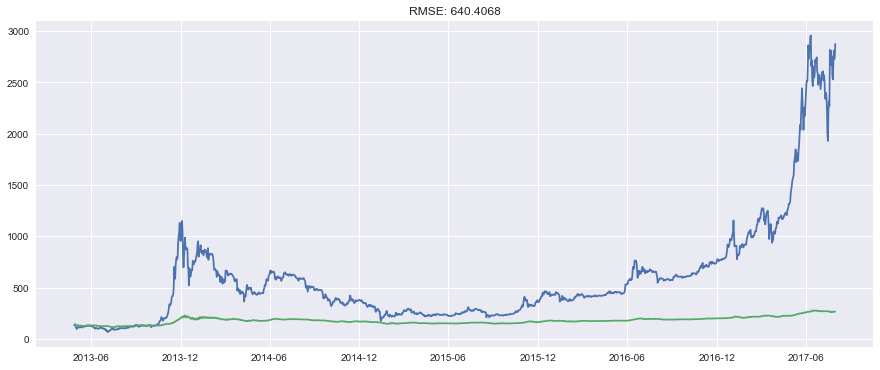

```python
predictions_ARIMA = np.exp(predictions_ARIMA_log)
plt.plot(data)
plt.plot(predictions_ARIMA)
plt.title('RMSE: %.4f'% np.sqrt(sum((predictions_ARIMA-data)**2)/len(data)))
```

```python
dates = [pd.Timestamp('2017-08-01'), pd.Timestamp('2017-08-02'), pd.Timestamp('2017-08-03'),pd.Timestamp('2017-08-04'), pd.Timestamp('2017-08-05'), pd.Timestamp('2017-08-06'), pd.Timestamp('2017-08-07')]

forecast = pd.Series(results_ARIMA.forecast(steps=7)[0],dates)
forecast = np.exp(forecast)
print(forecast)
error = mean_squared_error(test, forecast)
print('Test MSE: %.3f' % error)
```

```
2017-08-01    2872.404392
2017-08-02    2941.747337
2017-08-03    2992.008623
2017-08-04    3019.004229
2017-08-05    2956.525626
2017-08-06    2951.940463
2017-08-07    2987.949232
dtype: float64
Test MSE: 62392.694
```

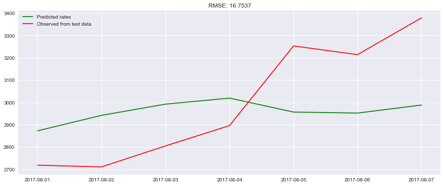

```python
plt.plot(forecast, color ='green', label ='Predicted rates')
plt.plot(test, color = 'red', label = 'Observed from test data')
plt.title('RMSE: %.4f'% np.sqrt(sum((forecast-test)**2)/len(data)))
plt.legend(loc = 'best')
```

## Using MA model to predict and forecast

Here we can see that the AR and MA, and the combined ARIMA models have almost the same RSS but MA model is significantly better in computational performance. So we use it to predict the price.

```python
predictions_MA_diff = pd.Series(results_MA.fittedvalues, copy=True)
print(predictions_MA_diff.head())
```

```
Date
2013-04-29    0.001941
2013-04-30    0.001458
2013-05-01    0.000081
2013-05-02    0.002704
2013-05-03    0.013811
dtype: float64
```

```python
predictions_MA_diff_cumsum = predictions_MA_diff.cumsum()
print(predictions_MA_diff_cumsum.head())
```

```
Date
2013-04-29    0.001941
2013-04-30    0.003399
2013-05-01    0.003479
2013-05-02    0.006184
2013-05-03    0.019995
dtype: float64
```

Notice that the predictions arent starting from 2013-04-28. This is because we took a lag by 1 and first element doesn’t have anything before it to subtract from. The way to convert the differencing to log scale is to add these differences consecutively to the base number. An easy way to do it is to first determine the cumulative sum at index and then add it to the base number

```python
predictions_MA_log = pd.Series(ts_logtransformed.iloc[0], index=ts_logtransformed.index)
predictions_MA_log = predictions_MA_log.add(predictions_MA_diff_cumsum,fill_value=0)
predictions_MA_log.head()
```

```
Date
2013-04-28    4.899406
2013-04-29    4.901347
2013-04-30    4.902805
2013-05-01    4.902885
2013-05-02    4.905590
dtype: float64
```

```
Text(0.5,1,'RMSE: 362.5192')
```

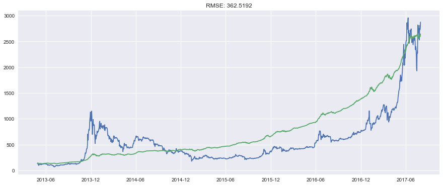

```python
predictions_MA = np.exp(predictions_MA_log)
plt.plot(data)
plt.plot(predictions_MA)
plt.title('RMSE: %.4f'% np.sqrt(sum((predictions_MA-data)**2)/len(data)))
```

```python
dates = [pd.Timestamp('2017-08-01'), pd.Timestamp('2017-08-02'), pd.Timestamp('2017-08-03'),pd.Timestamp('2017-08-04'), pd.Timestamp('2017-08-05'), pd.Timestamp('2017-08-06'), pd.Timestamp('2017-08-07')]

forecast = pd.Series(results_MA.forecast(steps=7)[0],dates)
forecast = np.exp(forecast)
print(forecast)
error = mean_squared_error(test, forecast)
print('Test MSE: %.3f' % error)
```

```
2017-08-01    2873.760683
2017-08-02    2933.263062
2017-08-03    2985.843908
2017-08-04    3001.085008
2017-08-05    2982.756000
2017-08-06    3057.337730
2017-08-07    3063.277569
dtype: float64
Test MSE: 44963.799
```

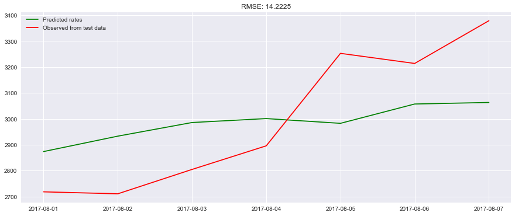

```python
plt.plot(forecast, color ='green', label ='Predicted rates')
plt.plot(test, color = 'red', label = 'Observed from test data')
plt.title('RMSE: %.4f'% np.sqrt(sum((forecast-test)**2)/len(data)))
plt.legend(loc = 'best')
```

Much work has to be done on eliminating hte seasonality in the above time series. More methods licke curve fitting and differnce can be extended to identify seasonality and remove the seasonal component from the data.

An improved model may be to subtract the average coin price from the same calendar month in the previous year, rather than the same day.

We can start off by resampling the dataset to a monthly average price. The resampling methods handles the concept of leap years while eliminating the offset (for example feb has only 28 days ).

```
Date
2013-04-30    139.250000
2013-05-31    119.993226
2013-06-30    107.761333
2013-07-31     90.512258
2013-08-31    113.905161
2013-09-30    130.061667
2013-10-31    158.311935
2013-11-30    550.420667
2013-12-31    800.780968
2014-01-31    844.168387
2014-02-28    661.618214
2014-03-31    592.200323
2014-04-30    461.362000
Freq: M, Name: Close, dtype: float64
```

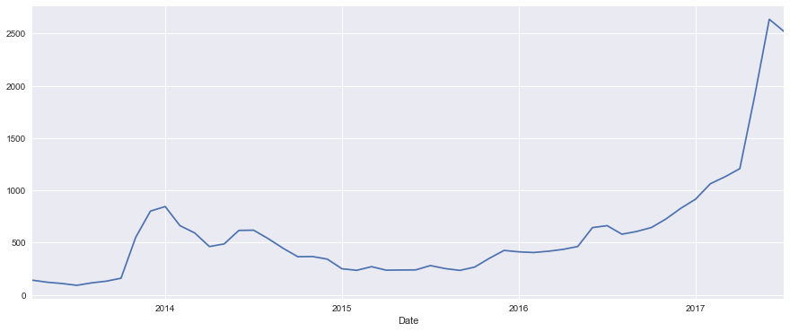

```python
monthly_mean = data.resample('M').mean()
monthly_mean
print(monthly_mean.head(13))
monthly_mean.plot()
```

## One more alternative to derive the forecasting performance

```python
test_logtransformed = np.log(test)
```

```python
history = [x for x in ts_logtransformed]
predictions = list()
for t in range(len(test)):
    output = results_MA.forecast()
    yhat = output[0]
    predictions.append(yhat)
    obs = test_logtransformed[t]
    history.append(obs)
    print('predicted=%f, expected=%f' % (yhat, obs))
error = mean_squared_error(test_logtransformed, predictions)
print('Test MSE: %.3f' % error)
```

```
predicted=7.963377, expected=7.907747
predicted=7.963377, expected=7.904951
predicted=7.963377, expected=7.939063
predicted=7.963377, expected=7.971048
predicted=7.963377, expected=8.087305
predicted=7.963377, expected=8.075253
predicted=7.963377, expected=8.125317
Test MSE: 0.009
```

Much work has to be done on eliminating hte seasonality in the above time series. More methods licke curve fitting and differnce can be extended to identify seasonality and remove the seasonal component from the data.

An improved model may be to subtract the average coin price from the same calendar month in the previous year, rather than the same day.

We can start off by resampling the dataset to a monthly average price. The resampling methods handles the concept of leap years while eliminating the offset (for example feb has only 28 days ).

```python
from fbprophet import Prophet
```

```python
data.head()
```

```
Date
2013-04-28    134.21
2013-04-29    144.54
2013-04-30    139.00
2013-05-01    116.99
2013-05-02    105.21
Name: Close, dtype: float64
```

```python
data_prophet = data.copy()
data_prophet = pd.DataFrame(data_prophet)
data_prophet.reset_index(drop=False, inplace=True)
data_prophet.columns =['ds','y']
data_prophet
```

|  | ds | y |
| --- | --- | --- |
| 0 | 2013-04-28 | 134.21 |
| 1 | 2013-04-29 | 144.54 |
| 2 | 2013-04-30 | 139.00 |
| 3 | 2013-05-01 | 116.99 |
| 4 | 2013-05-02 | 105.21 |
| 5 | 2013-05-03 | 97.75 |
| 6 | 2013-05-04 | 112.50 |
| 7 | 2013-05-05 | 115.91 |
| 8 | 2013-05-06 | 112.30 |
| 9 | 2013-05-07 | 111.50 |
| 10 | 2013-05-08 | 113.57 |
| 11 | 2013-05-09 | 112.67 |
| 12 | 2013-05-10 | 117.20 |
| 13 | 2013-05-11 | 115.24 |
| 14 | 2013-05-12 | 115.00 |
| 15 | 2013-05-13 | 117.98 |
| 16 | 2013-05-14 | 111.50 |
| 17 | 2013-05-15 | 114.22 |
| 18 | 2013-05-16 | 118.76 |
| 19 | 2013-05-17 | 123.02 |
| 20 | 2013-05-18 | 123.50 |
| 21 | 2013-05-19 | 121.99 |
| 22 | 2013-05-20 | 122.00 |
| 23 | 2013-05-21 | 122.88 |
| 24 | 2013-05-22 | 123.89 |
| 25 | 2013-05-23 | 126.70 |
| 26 | 2013-05-24 | 133.20 |
| 27 | 2013-05-25 | 131.98 |
| 28 | 2013-05-26 | 133.48 |
| 29 | 2013-05-27 | 129.75 |
| ... | ... | ... |
| 1526 | 2017-07-02 | 2506.47 |
| 1527 | 2017-07-03 | 2564.06 |
| 1528 | 2017-07-04 | 2601.64 |
| 1529 | 2017-07-05 | 2601.99 |
| 1530 | 2017-07-06 | 2608.56 |
| 1531 | 2017-07-07 | 2518.66 |
| 1532 | 2017-07-08 | 2571.34 |
| 1533 | 2017-07-09 | 2518.44 |
| 1534 | 2017-07-10 | 2372.56 |
| 1535 | 2017-07-11 | 2337.79 |
| 1536 | 2017-07-12 | 2398.84 |
| 1537 | 2017-07-13 | 2357.90 |
| 1538 | 2017-07-14 | 2233.34 |
| 1539 | 2017-07-15 | 1998.86 |
| 1540 | 2017-07-16 | 1929.82 |
| 1541 | 2017-07-17 | 2228.41 |
| 1542 | 2017-07-18 | 2318.88 |
| 1543 | 2017-07-19 | 2273.43 |
| 1544 | 2017-07-20 | 2817.60 |
| 1545 | 2017-07-21 | 2667.76 |
| 1546 | 2017-07-22 | 2810.12 |
| 1547 | 2017-07-23 | 2730.40 |
| 1548 | 2017-07-24 | 2754.86 |
| 1549 | 2017-07-25 | 2576.48 |
| 1550 | 2017-07-26 | 2529.45 |
| 1551 | 2017-07-27 | 2671.78 |
| 1552 | 2017-07-28 | 2809.01 |
| 1553 | 2017-07-29 | 2726.45 |
| 1554 | 2017-07-30 | 2757.18 |
| 1555 | 2017-07-31 | 2875.34 |

1556 rows × 2 columns

```
INFO:fbprophet.forecaster:Disabling daily seasonality. Run prophet with daily_seasonality=True to override this.
```

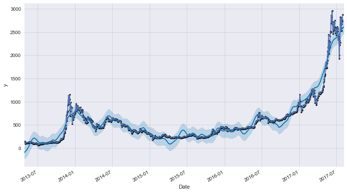

```python
m = Prophet()
m.fit(data_prophet)
future = m.make_future_dataframe(periods=7, freq='D')
forecast = m.predict(future)
m.plot(forecast)
data.plot()
```

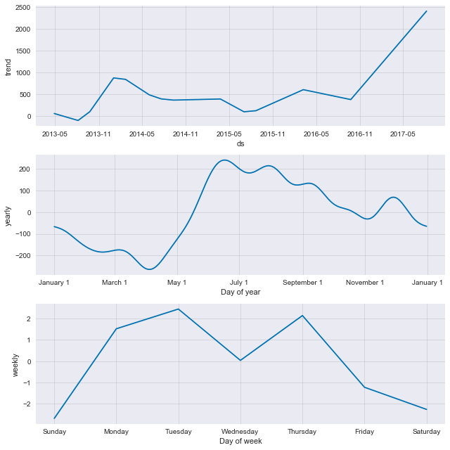

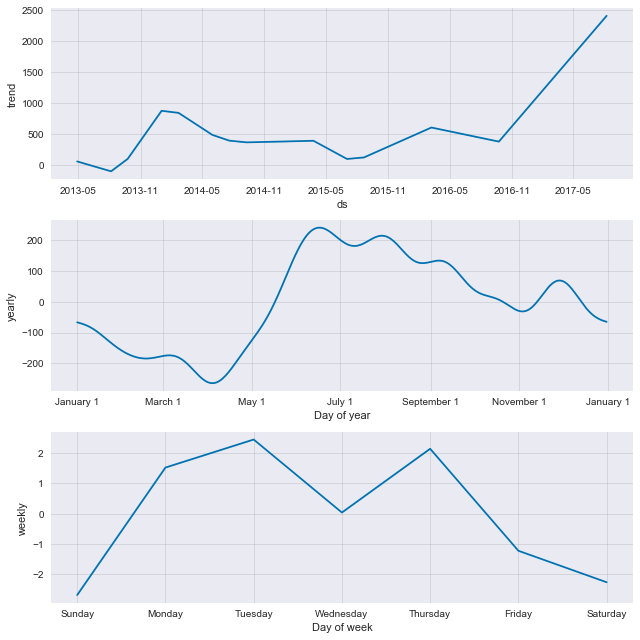

```python
m.plot_components(forecast)
```

```python
forecast.columns
```

```
Index(['ds', 'trend', 'trend_lower', 'trend_upper', 'yhat_lower', 'yhat_upper',
       'seasonal', 'seasonal_lower', 'seasonal_upper', 'seasonalities',
       'seasonalities_lower', 'seasonalities_upper', 'weekly', 'weekly_lower',
       'weekly_upper', 'yearly', 'yearly_lower', 'yearly_upper', 'yhat'],
      dtype='object')
```

```python
forecasted_values = forecast[['ds', 'yhat']].tail(7)
```

```python
forecasted_values = forecasted_values.set_index('ds')
forecasted_values.columns = ['y']
forecasted_values
```

| ds | y |
| --- | --- |
| 2017-08-01 | 2587.280931 |
| 2017-08-02 | 2589.612628 |
| 2017-08-03 | 2595.904578 |
| 2017-08-04 | 2596.199229 |
| 2017-08-05 | 2598.316597 |
| 2017-08-06 | 2600.587245 |
| 2017-08-07 | 2607.067188 |

```python
mean_squared_error(forecasted_values['y'],test)
```

```
223673.54034163457
```